# Multi-Class Classification Model for [PROJECT NAME] Using Python and AutoKeras Version 3

## Task 2 - Summarize and Visualize Data

```python
if NOTIFY_STATUS: status_notify("Task 2 - Summarize and Visualize Data has begun! " + datetime.now().strftime('%a %B %d, %Y %I:%M:%S %p'))
```

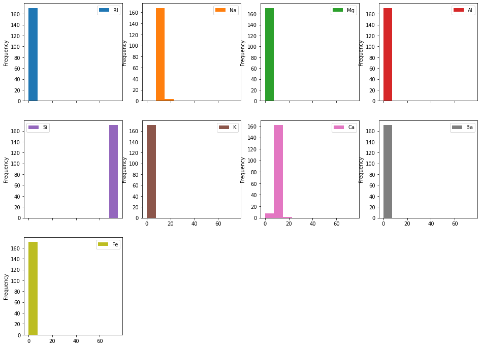

```python
# Histograms for each attribute
df_features_train.plot(kind='hist', subplots=True, layout=(display_rows, display_columns))
plt.show()
```

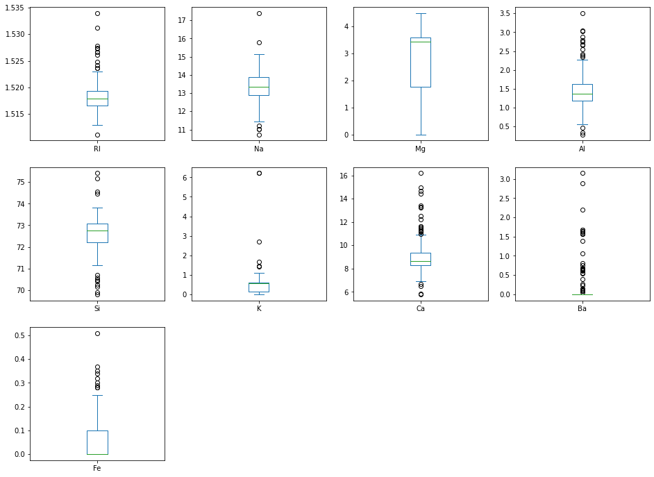

```python
# Box and Whisker plot for each attribute
df_features_train.plot(kind='box', subplots=True, layout=(display_rows, display_columns))
plt.show()
```

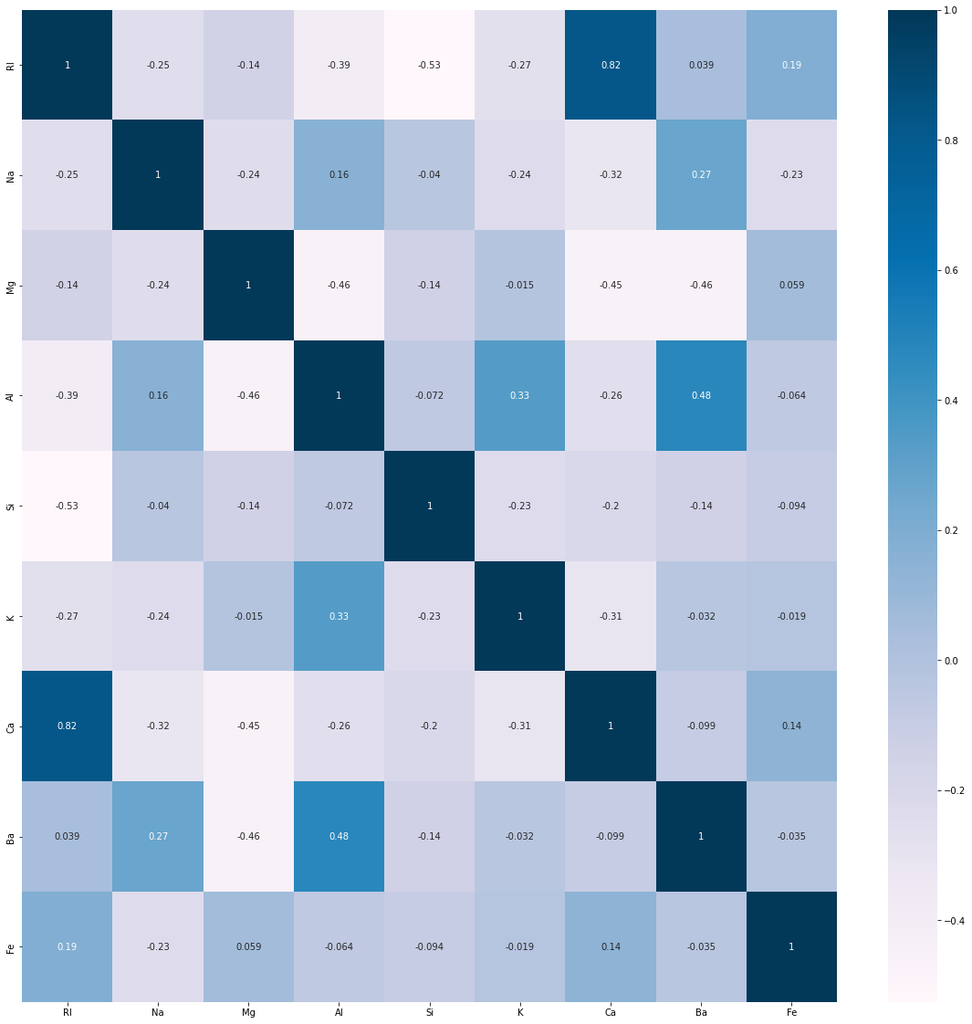

```python
# Correlation matrix
fig = plt.figure(figsize=(20, 20))
correlations = df_features_train.corr(method='pearson')
sns.heatmap(correlations, annot=True, cmap=plt.cm.PuBu)
plt.show()
```

```python
if NOTIFY_STATUS: status_notify("Task 2 - Summarize and Visualize Data completed! " + datetime.now().strftime('%a %B %d, %Y %I:%M:%S %p'))
```

## Task 3 - Pre-process Data

```python
if NOTIFY_STATUS: status_notify("Task 3 - Pre-process Data has begun! " + datetime.now().strftime('%a %B %d, %Y %I:%M:%S %p'))
```

### 3.a) Feature Scaling and Data Pre-Processing

```python
# Compose pipeline for the numerical and categorical features (Block #1 of 2)
numeric_columns = df_features_train.select_dtypes(include=['int64','float64']).columns
numeric_transformer = Pipeline(steps=[
    ('imputer', impute.SimpleImputer(strategy="constant", fill_value=0)),
    ('scaler', preprocessing.MinMaxScaler())
])
categorical_columns = df_features_train.select_dtypes(include=['object','bool','category']).columns
categorical_transformer = Pipeline(steps=[
    ('imputer', impute.SimpleImputer(strategy='constant', fill_value='UKNOWN')),
    ('onehot', preprocessing.OneHotEncoder(sparse=False, handle_unknown='ignore'))
])

print("Number of numerical columns:", len(numeric_columns))
print("Number of categorical columns:", len(categorical_columns))
print("Total number of columns in the feature dataframe:", df_features_train.shape[1])
```

```
Number of numerical columns: 9
Number of categorical columns: 0
Total number of columns in the feature dataframe: 9
```

```python
# Compose pipeline for the numerical and categorical features (Block #2 of 2)
preprocessor = compose.ColumnTransformer(transformers=[
    ('num', numeric_transformer, numeric_columns),
    ('cat', categorical_transformer, categorical_columns)
])

# Display the shapes of the training dataset for final inspection
array_features_train = preprocessor.fit_transform(df_features_train)
print("Transformed features from df_features_train.shape: {} to array_features_train.shape: {}".format(df_features_train.shape, array_features_train.shape))
```

```
Transformed features from df_features_train.shape: (171, 9) to array_features_train.shape: (171, 9)
```

### 3.b) Training Data Balancing

```python
# Not applicable for this iteration of the project
```

```python
# Perform SMOTE transformation on the training data (Block #1 of 2)

# X_train_imbal = X_train_df.values
# y_train_imbal = y_train_df.values.ravel()
# print("X_train_imbal.shape: {} y_train_imbal.shape: {}".format(X_train_imbal.shape, y_train_imbal.shape))
```

```python
# Perform SMOTE transformation on the training data (Block #2 of 2)

# print ('Original class distribution - 1: {} | 0: {}'.format((y_train_imbal==1).sum(), (y_train_imbal==0).sum()))
# sm = SMOTE(random_state=RNG_SEED, sampling_strategy=1.0)
# X_trainSmote, y_trainSmote = sm.fit_sample(X_train_imbal, y_train_imbal)
# print ('Resampled class distribution - 1: {} | 0: {}'.format((y_train==1).sum(), (y_train==0).sum()))
```

### 3.c) Display the Final Datasets for Model-Building

```python
# Finalize the training dataset for the modeling activities
# array_features_train = df_features_train.to_numpy()
# array_target_train = df_target_train.ravel()
label_encoder = preprocessing.LabelEncoder()
array_target_train = label_encoder.fit_transform(df_target_train)
print("array_features_train.shape: {} array_target_train.shape: {}".format(array_features_train.shape, array_target_train.shape))
```

```
array_features_train.shape: (171, 9) array_target_train.shape: (171,)
```

```python
if NOTIFY_STATUS: status_notify("Task 3 - Pre-process Data completed! " + datetime.now().strftime('%a %B %d, %Y %I:%M:%S %p'))
```

## Task 4 - Train and Tune Models

```python
if NOTIFY_STATUS: status_notify("Task 4 - Train and Tune Models has begun! " + datetime.now().strftime('%a %B %d, %Y %I:%M:%S %p'))
```

```python
start_time_module = datetime.now()
reset_random()
auto_model = ak.StructuredDataClassifier(loss=DEFAULT_LOSS,
                                         metrics=DEFAULT_METRICS,
                                         max_trials=MAX_TRIALS,
                                         objective=keras_tuner.Objective("val_accuracy", direction="max"),
                                         seed=RNG_SEED)
auto_model.fit(x=array_features_train,
               y=array_target_train,
               epochs=MAX_EPOCHS,
               validation_split=VAL_SET_RATIO,
               batch_size=BATCH_SIZE,
               verbose=1)
print('Total time for model fitting:', (datetime.now() - start_time_module))
```

```
Trial 70 Complete [00h 00m 03s]
val_accuracy: 0.6296296119689941

Best val_accuracy So Far: 0.7407407164573669
Total elapsed time: 00h 05m 27s
INFO:tensorflow:Oracle triggered exit
```

```
2022-01-05 19:20:14.017389: W tensorflow/python/util/util.cc:348] Sets are not currently considered sequences, but this may change in the future, so consider avoiding using them.
```

```
INFO:tensorflow:Assets written to: ./structured_data_classifier/best_model/assets
Total time for model fitting: 0:05:33.724107
```

```python
if NOTIFY_STATUS: status_notify("Task 4 - Train and Tune Models completed! " + datetime.now().strftime('%a %B %d, %Y %I:%M:%S %p'))
```

## Task 5 - Finalize Model and Make Predictions

```python
if NOTIFY_STATUS: status_notify("Task 5 - Finalize Model and Make Predictions has begun! " + datetime.now().strftime('%a %B %d, %Y %I:%M:%S %p'))
```

### 5.a) Train the Final Model

```python
final_model = auto_model.export_model()
final_model.summary()
```

```
Model: "model"
_________________________________________________________________
Layer (type)                 Output Shape              Param #
=================================================================
input_1 (InputLayer)         [(None, 9)]               0
_________________________________________________________________
multi_category_encoding (Mul (None, 9)                 0
_________________________________________________________________
normalization (Normalization (None, 9)                 19
_________________________________________________________________
dense (Dense)                (None, 32)                320
_________________________________________________________________
batch_normalization (BatchNo (None, 32)                128
_________________________________________________________________
re_lu (ReLU)                 (None, 32)                0
_________________________________________________________________
dense_1 (Dense)              (None, 32)                1056
_________________________________________________________________
batch_normalization_1 (Batch (None, 32)                128
_________________________________________________________________
re_lu_1 (ReLU)               (None, 32)                0
_________________________________________________________________
dense_2 (Dense)              (None, 6)                 198
_________________________________________________________________
classification_head_1 (Softm (None, 6)                 0
=================================================================
Total params: 1,849
Trainable params: 1,702
Non-trainable params: 147
_________________________________________________________________
```

### 5.b) Load Test Dataset and Make Predictions

```python
# Finalize the test dataset for the testing activities
array_features_test = preprocessor.transform(df_features_test)
array_target_test = label_encoder.transform(df_target_test)
print("array_features_test.shape: {} array_target_test.shape: {}".format(array_features_test.shape, array_target_test.shape))
```

```
array_features_test.shape: (43, 9) array_target_test.shape: (43,)
```

```python
# Make batched predictions
test_predictions =  np.argmax(final_model.predict(array_features_test), axis=-1)
print(test_predictions)
```

```
[1 0 0 1 4 1 1 5 0 1 1 1 1 1 1 1 3 3 0 0 5 2 0 0 3 1 0 0 5 1 0 1 0 1 1 1 1
 0 5 5 1 1 1]
```

```python
print('Accuracy Score:', accuracy_score(array_target_test, test_predictions), '\n')
print(confusion_matrix(array_target_test, test_predictions), '\n')
print(classification_report(array_target_test, test_predictions))
```

```
Accuracy Score: 0.7674418604651163

[[12  5  0  0  0  0]
 [ 0 14  0  1  0  0]
 [ 0  1  1  0  0  0]
 [ 0  0  0  1  0  1]
 [ 0  0  0  0  1  0]
 [ 0  1  0  1  0  4]]

              precision    recall  f1-score   support

           0       1.00      0.71      0.83        17
           1       0.67      0.93      0.78        15
           2       1.00      0.50      0.67         2
           3       0.33      0.50      0.40         2
           4       1.00      1.00      1.00         1
           5       0.80      0.67      0.73         6

    accuracy                           0.77        43
   macro avg       0.80      0.72      0.73        43
weighted avg       0.82      0.77      0.77        43
```

```python
if NOTIFY_STATUS: status_notify("Task 5 - Finalize Model and Make Predictions completed! " + datetime.now().strftime('%a %B %d, %Y %I:%M:%S %p'))
```

```python
print ('Total time for the script:',(datetime.now() - START_TIME_SCRIPT))
```

```
Total time for the script: 0:05:37.102407
```